# Assignment 2 - Rama Kanetkar, Zhengping Duan, Ziqi Liu

```r
library(tidyverse)
library(reshape2)
```

```r
library(ggplot2)
library(xts)
library(zoo)
house.data <- read.csv("kc_house_data.csv")
```

SECTION 1: Location analysis This section analyses the relationship between location and house price. The involved columns are: 1) Zip code 2) latitude 3) longititude

```r
price_location <- house.data[,c(3,17,18,19)]
zipCode_Price <- price_location[,c(1,2)]
groupped <- melt(zipCode_Price,id.vars = c("price","zipcode")) %>% group_by(zipcode)
priceByZipcode <- groupped %>% summarise( price = mean(price))
priceByZipcode <- priceByZipcode[order(-priceByZipcode$price),]
priceByZipcode$zipcode <- factor(priceByZipcode$zipcode, levels = priceByZipcode$zipcode)
TopTenPrice <- head(priceByZipcode,n = 10)
```

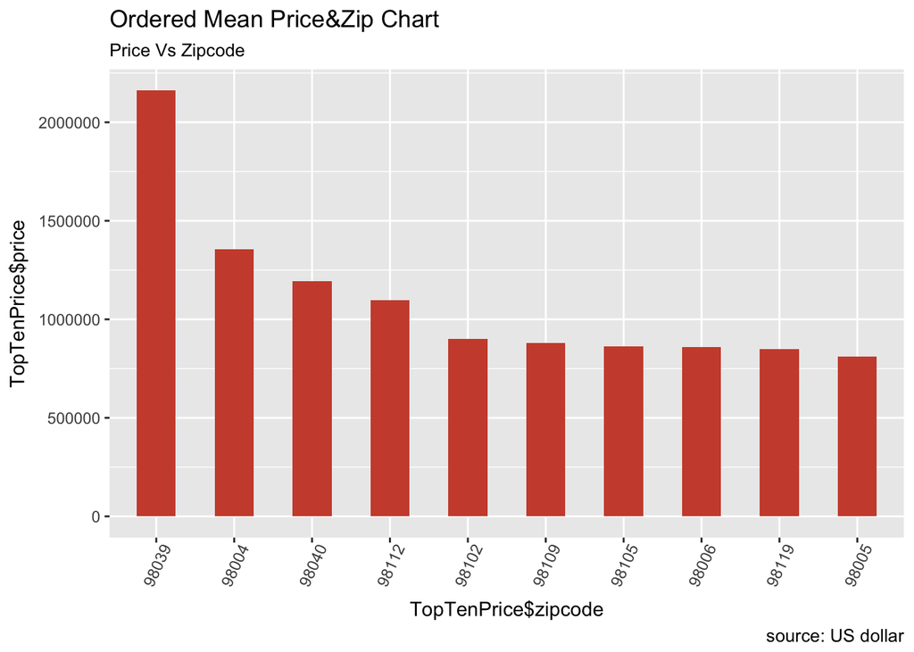

```r
ggplot(TopTenPrice, aes(x=TopTenPrice$zipcode, y=TopTenPrice$price)) +
  geom_bar(stat="identity", width=.5, fill="tomato3") +
  labs(title="Ordered Mean Price&Zip Chart",
       subtitle="Price Vs Zipcode",
       caption="source: US dollar") +
  theme(axis.text.x = element_text(angle=65, vjust=0.6))
```

SECTION 2: Time series analysis Involved column: Date

```r
library(zoo)

housePriceByTime <- house.data[,c(2,3)]
housePriceByTime[,1]<- substr(housePriceByTime[,1],start = 1,stop = 8)
housePriceByTime[,1]<- as.Date(housePriceByTime[,1],"%Y%m%d")
housePriceByTime$price <- as.numeric(housePriceByTime$price)
housePriceByTime <- xts(as.matrix(housePriceByTime[,-1]), order.by = housePriceByTime$date)
```

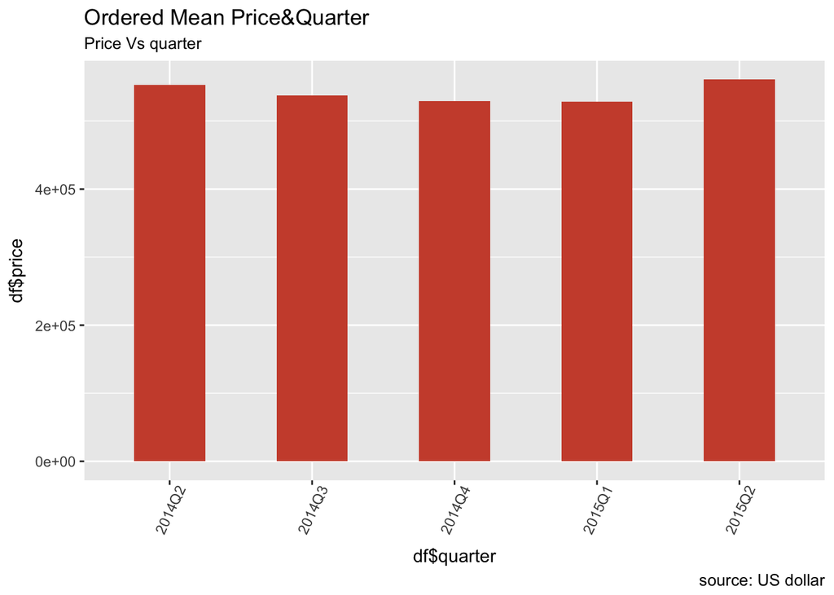

```r
xts5_quarterly <- split(housePriceByTime,f="quarters")
quaterlyAvgPrice <- lapply(xts5_quarterly,FUN=mean)
df <- data.frame("price" = round(as.numeric(quaterlyAvgPrice),2),"quarter"=c("2014Q2","2014Q3","2014Q4","2015Q1","2015Q2"))


ggplot(data=df,mapping = aes(x = df$quarter,y = df$price))+
  geom_bar(stat="identity", width=.5, fill="tomato3") +
  labs(title="Ordered Mean Price&Quarter",
       subtitle="Price Vs quarter",
       caption="source: US dollar") +
  theme(axis.text.x = element_text(angle=65, vjust=0.6))
```

SECTION 3: House condition analysis Invovled column: 1) condition 2_ year_built 3) year_renovated This section aims to analyze the correlation between the condition of the house and the selling price.

```r
HouseCondition <- house.data[,c(3,11,15,16)]

cor.test(HouseCondition$price,HouseCondition$condition)
```

```
##
##  Pearson's product-moment correlation
##
## data:  HouseCondition$price and HouseCondition$condition
## t = 5.349, df = 21611, p-value = 8.936e-08
## alternative hypothesis: true correlation is not equal to 0
## 95 percent confidence interval:
##  0.02304097 0.04966970
## sample estimates:
##        cor
## 0.03636179
```

```r
cor.test(HouseCondition$price,HouseCondition$yr_built)
```

```
##
##  Pearson's product-moment correlation
##
## data:  HouseCondition$price and HouseCondition$yr_built
## t = 7.9517, df = 21611, p-value = 1.93e-15
## alternative hypothesis: true correlation is not equal to 0
## 95 percent confidence interval:
##  0.04070886 0.06729506
## sample estimates:
##        cor
## 0.05401153
```

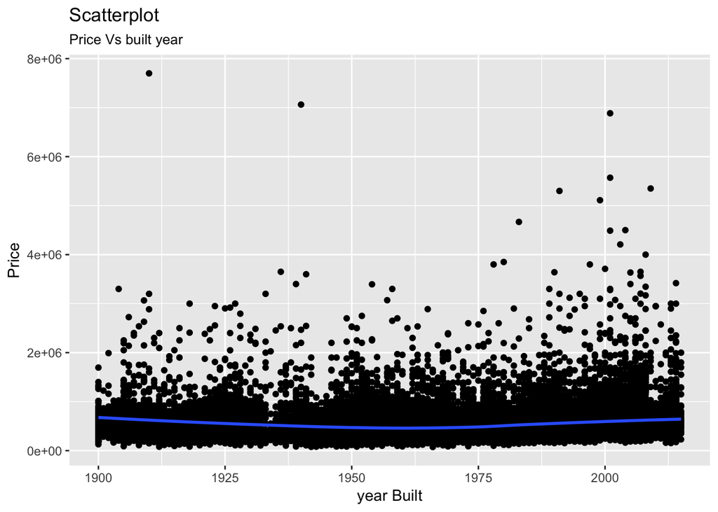

```r
ggplot(HouseCondition, aes(x=yr_built, y=price)) +
  geom_point() +
  geom_smooth(method="loess", se=F) +
  labs(subtitle="Price Vs built year",
       y="Price",
       x="year Built",
       title="Scatterplot" )
```

```r
cor.test(HouseCondition$price,HouseCondition$yr_renovated)
```

```
##
##  Pearson's product-moment correlation
##
## data:  HouseCondition$price and HouseCondition$yr_renovated
## t = 18.737, df = 21611, p-value < 2.2e-16
## alternative hypothesis: true correlation is not equal to 0
## 95 percent confidence interval:
##  0.1132928 0.1395306
## sample estimates:
##       cor
## 0.1264338
```

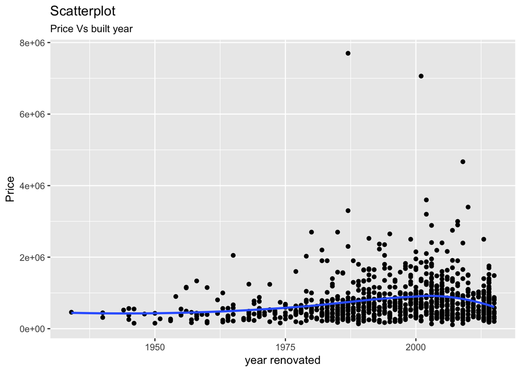

```r
revocated_Yes <- HouseCondition[HouseCondition[,4]!= 0,]
ggplot(revocated_Yes, aes(x=yr_renovated, y=price)) +
  geom_point() +
  geom_smooth(method="loess", se=F) +
  labs(subtitle="Price Vs built year",
       y="Price",
       x="year renovated",
       title="Scatterplot" )
```

SECTION 4: Grade analysis Invovled coloumn: grade Each buyers have grade of each house given by real estate agency for reference. We want to exam if the associated grade will influence the price of the house

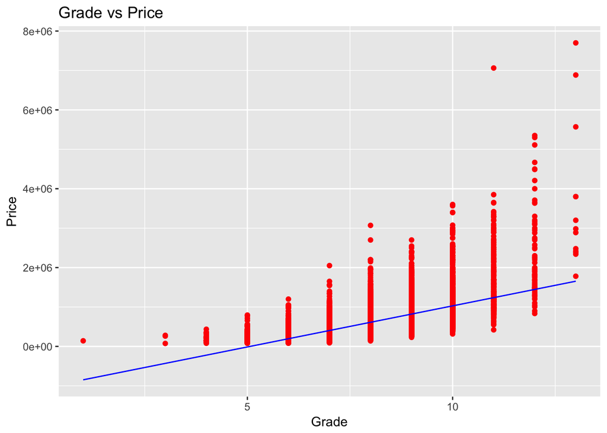

```r
HouseGrade <- house.data[,c(3,12)]
fit <- lm(HouseGrade$price~HouseGrade$grade)

ggplot() +
  geom_point(aes(x = HouseGrade$grade, y =HouseGrade$price),
             colour = 'red') +
  geom_line(aes(x = HouseGrade$grade, y = fit$coefficients[1]+fit$coefficients[2]*as.numeric(HouseGrade$grade)),
            colour = 'blue') +
  ggtitle('Grade vs Price') +
  xlab('Grade') +
  ylab('Price')
```

SECTION 5: View Analysis Invovled column: view In this section, we want to analyze if house price is related to number of views by other potential buyers. We suspect that more views might result high price.

```r
colnames(house.data)
```

```
##  [1] "id"            "date"          "price"         "bedrooms"
##  [5] "bathrooms"     "sqft_living"   "sqft_lot"      "floors"
##  [9] "waterfront"    "view"          "condition"     "grade"
## [13] "sqft_above"    "sqft_basement" "yr_built"      "yr_renovated"
## [17] "zipcode"       "lat"           "long"          "sqft_living15"
## [21] "sqft_lot15"
```

```r
HouseView <- house.data[,c(3,10)]
cor.test(HouseView$price,HouseView$view)
```

```
##
##  Pearson's product-moment correlation
##
## data:  HouseView$price and HouseView$view
## t = 63.643, df = 21611, p-value < 2.2e-16
## alternative hypothesis: true correlation is not equal to 0
## 95 percent confidence interval:
##  0.3860061 0.4084620
## sample estimates:
##       cor
## 0.3972935
```

```r
house.infrastruct = house.data[,c(1,3,4,5,8,9,13,14,20,21)]
head(house.infrastruct)
```

```
##           id   price bedrooms bathrooms floors waterfront sqft_above
## 1 7129300520  221900        3      1.00      1          0       1180
## 2 6414100192  538000        3      2.25      2          0       2170
## 3 5631500400  180000        2      1.00      1          0        770
## 4 2487200875  604000        4      3.00      1          0       1050
## 5 1954400510  510000        3      2.00      1          0       1680
## 6 7237550310 1225000        4      4.50      1          0       3890
##   sqft_basement sqft_living15 sqft_lot15
## 1             0          1340       5650
## 2           400          1690       7639
## 3             0          2720       8062
## 4           910          1360       5000
## 5             0          1800       7503
## 6          1530          4760     101930
```

```r
sapply(house.infrastruct,summary)
```

```
##                id   price bedrooms bathrooms floors waterfront sqft_above
## Min.    1.000e+06   75000    0.000     0.000  1.000   0.000000        290
## 1st Qu. 2.123e+09  322000    3.000     1.750  1.000   0.000000       1190
## Median  3.905e+09  450000    3.000     2.250  1.500   0.000000       1560
## Mean    4.580e+09  540100    3.371     2.115  1.494   0.007542       1788
## 3rd Qu. 7.309e+09  645000    4.000     2.500  2.000   0.000000       2210
## Max.    9.900e+09 7700000   33.000     8.000  3.500   1.000000       9410
##         sqft_basement sqft_living15 sqft_lot15
## Min.              0.0           399        651
## 1st Qu.           0.0          1490       5100
## Median            0.0          1840       7620
## Mean            291.5          1987      12770
## 3rd Qu.         560.0          2360      10080
## Max.           4820.0          6210     871200
```

```r
find.aggregate <- function(agg.col,grpby.col) {

  tempDF <- aggregate(agg.col ~ grpby.col, house.infrastruct,mean)
  barplot(tempDF$agg.col,ylab = "House Price", names.arg = tempDF$grpby.col)
}
```

```r
cor.test(house.infrastruct$price,house.infrastruct$bedrooms)
```

```
##
##  Pearson's product-moment correlation
##
## data:  house.infrastruct$price and house.infrastruct$bedrooms
## t = 47.651, df = 21611, p-value < 2.2e-16
## alternative hypothesis: true correlation is not equal to 0
## 95 percent confidence interval:
##  0.2962354 0.3203646
## sample estimates:
##       cor
## 0.3083496
```

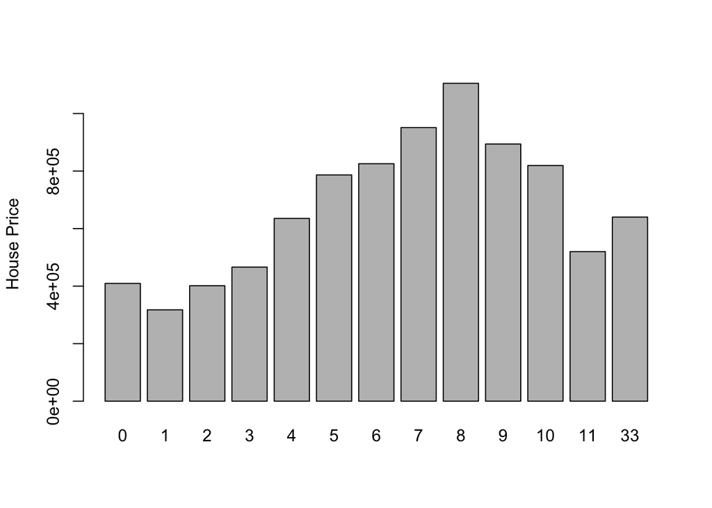

```r
find.aggregate(house.infrastruct$price,house.infrastruct$bedrooms)
```

```r
cor.test(house.infrastruct$price,house.infrastruct$bathrooms)
```

```
##
##  Pearson's product-moment correlation
##
## data:  house.infrastruct$price and house.infrastruct$bathrooms
## t = 90.714, df = 21611, p-value < 2.2e-16
## alternative hypothesis: true correlation is not equal to 0
## 95 percent confidence interval:
##  0.5154140 0.5347258
## sample estimates:
##       cor
## 0.5251375
```

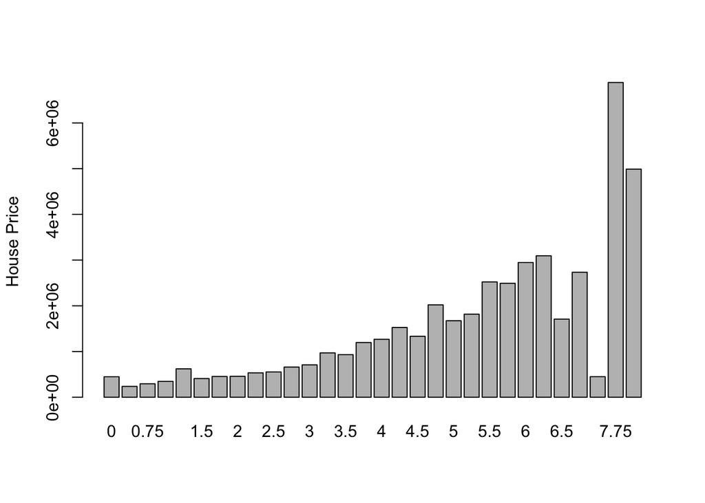

```r
find.aggregate(house.infrastruct$price,house.infrastruct$bathrooms)
```

```r
cor.test(house.infrastruct$price,house.infrastruct$floors)
```

```
##
##  Pearson's product-moment correlation
##
## data:  house.infrastruct$price and house.infrastruct$floors
## t = 39.06, df = 21611, p-value < 2.2e-16
## alternative hypothesis: true correlation is not equal to 0
## 95 percent confidence interval:
##  0.2442983 0.2692042
## sample estimates:
##       cor
## 0.2567939
```

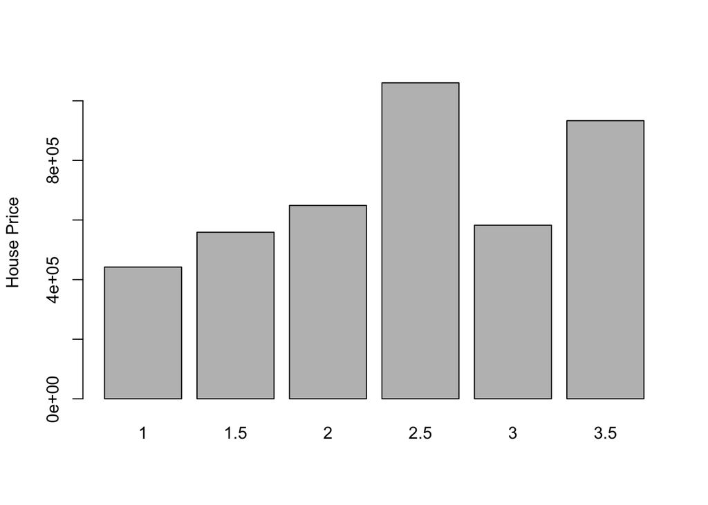

```r
find.aggregate(house.infrastruct$price,house.infrastruct$floors)
```

```r
cor.test(house.infrastruct$price,house.infrastruct$waterfront)
```

```
##
##  Pearson's product-moment correlation
##
## data:  house.infrastruct$price and house.infrastruct$waterfront
## t = 40.626, df = 21611, p-value < 2.2e-16
## alternative hypothesis: true correlation is not equal to 0
## 95 percent confidence interval:
##  0.2539392 0.2787117
## sample estimates:
##       cor
## 0.2663694
```

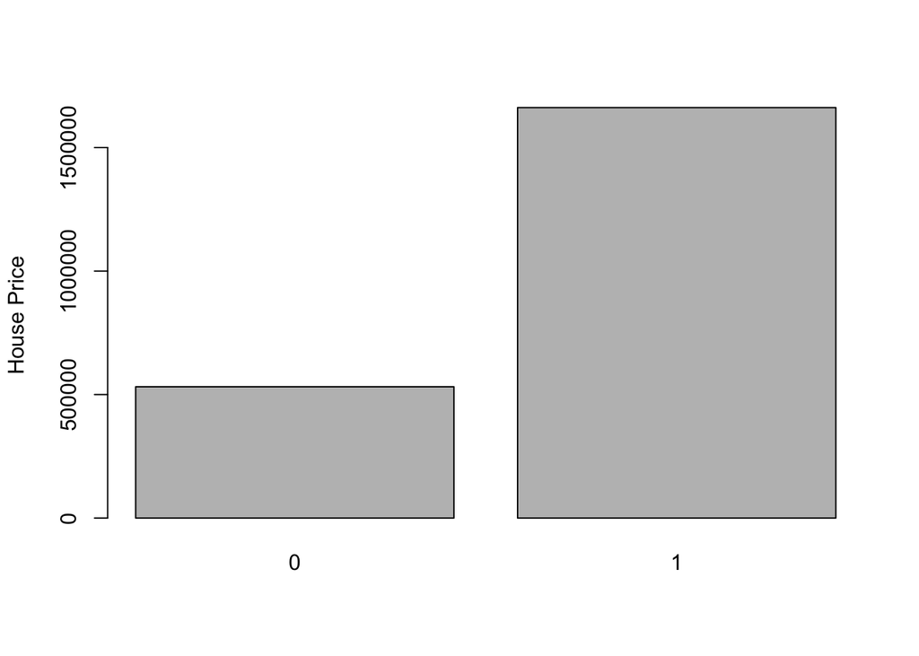

```r
find.aggregate(house.infrastruct$price,house.infrastruct$waterfront)
```

```r
cor.test(house.infrastruct$price,house.infrastruct$sqft_above)
```

```
##
##  Pearson's product-moment correlation
##
## data:  house.infrastruct$price and house.infrastruct$sqft_above
## t = 111.87, df = 21611, p-value < 2.2e-16
## alternative hypothesis: true correlation is not equal to 0
## 95 percent confidence interval:
##  0.5970556 0.6139427
## sample estimates:
##       cor
## 0.6055673
```

```r
cor.test(house.infrastruct$price,house.infrastruct$sqft_basement)
```

```
##
##  Pearson's product-moment correlation
##
## data:  house.infrastruct$price and house.infrastruct$sqft_basement
## t = 50.314, df = 21611, p-value < 2.2e-16
## alternative hypothesis: true correlation is not equal to 0
## 95 percent confidence interval:
##  0.3118302 0.3356988
## sample estimates:
##      cor
## 0.323816
```

```r
cor.test(house.infrastruct$price,house.infrastruct$sqft_living15)
```

```
##
##  Pearson's product-moment correlation
##
## data:  house.infrastruct$price and house.infrastruct$sqft_living15
## t = 106.14, df = 21611, p-value < 2.2e-16
## alternative hypothesis: true correlation is not equal to 0
## 95 percent confidence interval:
##  0.5765464 0.5940746
## sample estimates:
##       cor
## 0.5853789
```

```r
cor.test(house.infrastruct$price,house.infrastruct$sqft_lot15)
```

```
##
##  Pearson's product-moment correlation
##
## data:  house.infrastruct$price and house.infrastruct$sqft_lot15
## t = 12.162, df = 21611, p-value < 2.2e-16
## alternative hypothesis: true correlation is not equal to 0
## 95 percent confidence interval:
##  0.06919122 0.09567398
## sample estimates:
##        cor
## 0.08244715
```

```r
cor(house.infrastruct)
```

```
##                         id       price     bedrooms   bathrooms
## id             1.000000000 -0.01676220  0.001286277 0.005160232
## price         -0.016762197  1.00000000  0.308349598 0.525137505
## bedrooms       0.001286277  0.30834960  1.000000000 0.515883638
## bathrooms      0.005160232  0.52513751  0.515883638 1.000000000
## floors         0.018525229  0.25679389  0.175428935 0.500653173
## waterfront    -0.002721094  0.26636943 -0.006582479 0.063743629
## sqft_above    -0.010842134  0.60556730  0.477600161 0.685342476
## sqft_basement -0.005151125  0.32381602  0.303093375 0.283770034
## sqft_living15 -0.002901004  0.58537890  0.391637524 0.568634290
## sqft_lot15    -0.138797866  0.08244715  0.029244224 0.087175361
##                    floors   waterfront  sqft_above sqft_basement
## id             0.01852523 -0.002721094 -0.01084213  -0.005151125
## price          0.25679389  0.266369434  0.60556730   0.323816021
## bedrooms       0.17542894 -0.006582479  0.47760016   0.303093375
## bathrooms      0.50065317  0.063743629  0.68534248   0.283770034
## floors         1.00000000  0.023698320  0.52388471  -0.245704542
## waterfront     0.02369832  1.000000000  0.07207459   0.080587939
## sqft_above     0.52388471  0.072074592  1.00000000  -0.051943307
## sqft_basement -0.24570454  0.080587939 -0.05194331   1.000000000
## sqft_living15  0.27988527  0.086463136  0.73187029   0.200354983
## sqft_lot15    -0.01126919  0.030703283  0.19404986   0.017276181
##               sqft_living15  sqft_lot15
## id             -0.002901004 -0.13879787
## price           0.585378904  0.08244715
## bedrooms        0.391637524  0.02924422
## bathrooms       0.568634290  0.08717536
## floors          0.279885265 -0.01126919
## waterfront      0.086463136  0.03070328
## sqft_above      0.731870292  0.19404986
## sqft_basement   0.200354983  0.01727618
## sqft_living15   1.000000000  0.18319175
## sqft_lot15      0.183191749  1.00000000
```